# Team 3 Lab-1 Write-Up

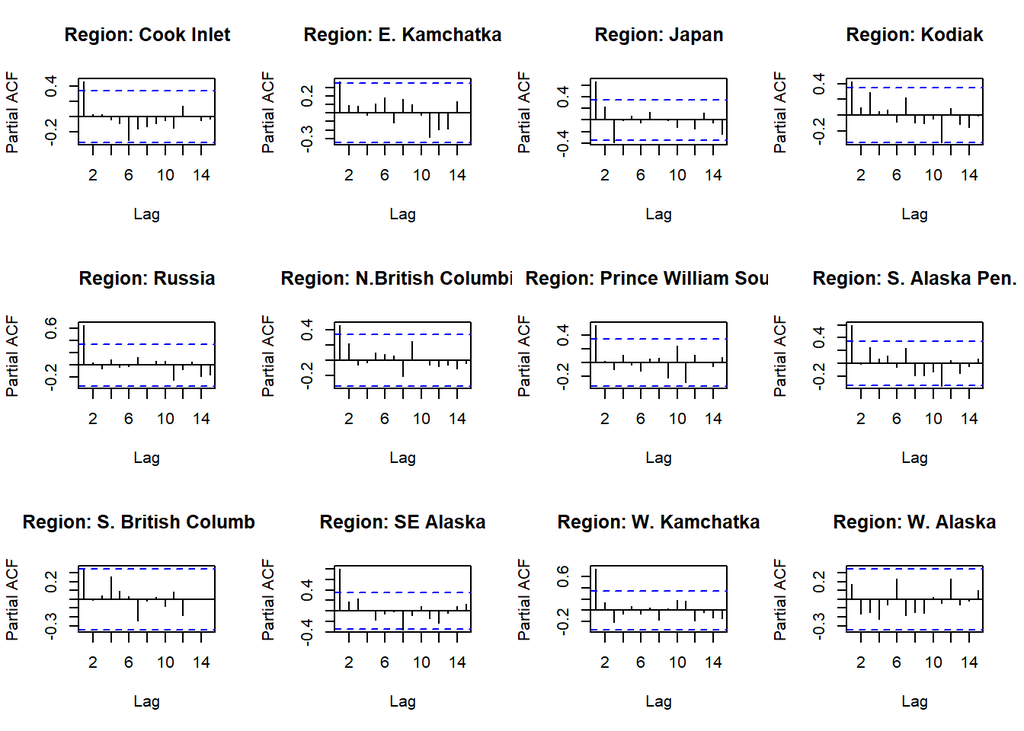

```r
#PACF plots for each region
par(mfrow=c(3,4))
for(r in 1:length(regions)){
  plot(DiagPlots_odd[[r]][[2]], main = paste0("Region: ", regionskey[r]))
}
```

The next step is to look at the ARIMA models for regions by all years, even and odd years, and define forecast levels. Let’s start with all years.

```r
#forecast levels
forecastlevels<-c(5, 10, 20)
#all combinations
Allcombs<-expand_grid(regions, forecastlevels)

#================================================

#All
RegionMods<-mapply(FitModFunction, Allcombs$regions, Allcombs$forecastlevels, SIMPLIFY = FALSE)
# head(RegionMods_even)
# names(RegionMods_even)
```

Now let’s consider even years.

```r
#Even
RegionMods_even<-mapply(FitModFunction_even, Allcombs$regions, Allcombs$forecastlevels, SIMPLIFY = FALSE)
head(RegionMods_even)
```

```
## $ci
## $ci$Fit
## Series: train
## ARIMA(0,1,0)
##
## sigma^2 = 0.3224:  log likelihood = -23.88
## AIC=49.77   AICc=49.92   BIC=51.1
##
## $ci$MASE
## [1] 0.3602762
##
## $ci$Bm
##                                  V1        V2      AIC DeltaAIC     Mod npar
## 1  ARIMA(0,1,0)                      55.48062 55.48062        0 0, 1, 0    0
##
##
## $ci
## $ci$Fit
## Series: train
## ARIMA(0,1,0)
##
## sigma^2 = 0.3052:  log likelihood = -21.47
## AIC=44.93   AICc=45.1   BIC=46.19
##
## $ci$MASE
## [1] 1.243461
##
## $ci$Bm
##                                  V1        V2      AIC DeltaAIC     Mod npar
## 1  ARIMA(0,1,0)                      55.48062 55.48062        0 0, 1, 0    0
##
##
## $ci
## $ci$Fit
## Series: train
## ARIMA(0,1,0)
##
## sigma^2 = 0.2563:  log likelihood = -15.5
## AIC=33.01   AICc=33.22   BIC=34.05
##
```

[output cut: 66 more lines]

```
## s.e.  0.1209
##
## sigma^2 = 0.337:  log likelihood = -18.74
## AIC=41.48   AICc=42.12   BIC=43.67
##
## $e_kam$MASE
## [1] 0.2382605
##
## $e_kam$Bm
##                                  V1        V2      AIC DeltaAIC     Mod npar
## 1  ARIMA(0,0,0) with non-zero mean   71.15545 71.15545  0.43946 0, 0, 0    0
## 2  ARIMA(1,0,0) with non-zero mean   72.55604 72.55604  1.84005 1, 0, 0    1
## 3  ARIMA(0,0,1) with non-zero mean   70.71599 70.71599  0.00000 0, 0, 1    1
## 4  ARIMA(1,0,1) with non-zero mean   72.39343 72.39343  1.67744 1, 0, 1    2
## 5  ARIMA(0,0,2) with non-zero mean   71.53128 71.53128  0.81529 0, 0, 2    2
```

```r
#names(RegionMods_even) #should be three for each region
```

Now let’s consider odd years.

```r
#Odd
RegionMods_odd<-mapply(FitModFunction_odd, Allcombs$regions, Allcombs$forecastlevels, SIMPLIFY = FALSE)
head(RegionMods_odd)
```

```
## $ci
## $ci$Fit
## Series: train
## ARIMA(1,0,0) with zero mean
##
## Coefficients:
##          ar1
##       0.6039
## s.e.  0.1467
##
## sigma^2 = 0.4057:  log likelihood = -27.79
## AIC=59.57   AICc=60.03   BIC=62.31
##
## $ci$MASE
## [1] 2.144842
##
## $ci$Bm
##                                  V1        V2      AIC DeltaAIC     Mod npar
## 1  ARIMA(1,0,0) with non-zero mean    75.3159 75.31590  0.36364 1, 0, 0    1
## 2  ARIMA(1,0,0) with zero mean       74.95226 74.95226  0.00000 1, 0, 0    1
##
##
## $ci
## $ci$Fit
## Series: train
## ARIMA(1,0,0) with zero mean
##
## Coefficients:
##          ar1
##       0.6037
## s.e.  0.1610
##
## sigma^2 = 0.4189:  log likelihood = -26.28
## AIC=56.57   AICc=57.07   BIC=59.16
##
## $ci$MASE
## [1] 1.555645
##
## $ci$Bm
##                                  V1        V2      AIC DeltaAIC     Mod npar
```

[output cut: 70 more lines]

```
## Coefficients:
##          ma1    mean
##       0.5404  3.9140
## s.e.  0.1481  0.1168
##
## sigma^2 = 0.1433:  log likelihood = -8.97
## AIC=23.94   AICc=25.28   BIC=27.21
##
## $e_kam$MASE
## [1] 0.1918676
##
## $e_kam$Bm
##                                  V1        V2      AIC DeltaAIC     Mod npar
## 1  ARIMA(1,1,0) with drift           60.55848 60.55848  1.02617 1, 1, 0    2
## 2  ARIMA(0,1,0)                      59.53231 59.53231  0.00000 0, 1, 0    0
```

```r
#names(RegionMods_odd) #should be three for each region
```

Now, we’re extracting the MASE and creating our final model tables

```r
#getting MASE
#All
RegionMASE<-sapply(RegionMods, function(x){y<-x$MASE})
RegionBestMod<-sapply(RegionMods, function(x){y<-as.character(x$Fit)})
#Even
RegionMASE_even<-sapply(RegionMods_even, function(x){y<-x$MASE})
RegionBestMod_even<-sapply(RegionMods_even, function(x){y<-as.character(x$Fit)})
#Odd
RegionMASE_odd<-sapply(RegionMods_odd, function(x){y<-x$MASE})
RegionBestMod_odd<-sapply(RegionMods_odd, function(x){y<-as.character(x$Fit)})
#combine into tables
#all
ResultsTable<-Allcombs %>% add_column(Model = RegionBestMod, MASE = RegionMASE)
ResultsTable
```

```
## # A tibble: 36 × 4
##    regions forecastlevels Model                            MASE
##    <chr>            <dbl> <chr>                           <dbl>
##  1 ci                   5 ARIMA(2,0,0) with non-zero mean 0.460
##  2 ci                  10 ARIMA(2,0,0) with non-zero mean 0.549
##  3 ci                  20 ARIMA(1,0,1) with non-zero mean 0.711
##  4 e_kam                5 ARIMA(2,0,0) with non-zero mean 0.134
##  5 e_kam               10 ARIMA(2,0,0) with non-zero mean 0.111
##  6 e_kam               20 ARIMA(2,0,0) with non-zero mean 0.196
##  7 japan                5 ARIMA(0,0,0) with non-zero mean 0.744
##  8 japan               10 ARIMA(0,0,0) with non-zero mean 0.901
##  9 japan               20 ARIMA(0,1,1)                    0.853
## 10 kod                  5 ARIMA(0,1,1) with drift         0.221
## # ℹ 26 more rows
```

```r
#even
ResultsTable_even<-Allcombs %>% add_column(Model = RegionBestMod_even, MASE = RegionMASE_even)
ResultsTable_even
```

```
## # A tibble: 36 × 4
##    regions forecastlevels Model                            MASE
##    <chr>            <dbl> <chr>                           <dbl>
##  1 ci                   5 ARIMA(0,1,0)                    0.360
##  2 ci                  10 ARIMA(0,1,0)                    1.24
##  3 ci                  20 ARIMA(0,1,0)                    0.395
##  4 e_kam                5 ARIMA(0,0,0) with non-zero mean 0.240
##  5 e_kam               10 ARIMA(0,0,0) with non-zero mean 0.219
##  6 e_kam               20 ARIMA(0,0,0) with non-zero mean 0.238
##  7 japan                5 ARIMA(0,1,0)                    0.743
##  8 japan               10 ARIMA(0,1,0)                    0.500
##  9 japan               20 ARIMA(1,0,0) with non-zero mean 0.731
## 10 kod                  5 ARIMA(0,0,0) with non-zero mean 0.155
## # ℹ 26 more rows
```

```r
#Odd
ResultsTable_odd<-Allcombs %>% add_column(Model = RegionBestMod_odd, MASE = RegionMASE_odd)
ResultsTable_odd
```

```
## # A tibble: 36 × 4
##    regions forecastlevels Model                            MASE
##    <chr>            <dbl> <chr>                           <dbl>
##  1 ci                   5 ARIMA(1,0,0) with zero mean     2.14
##  2 ci                  10 ARIMA(1,0,0) with zero mean     1.56
##  3 ci                  20 ARIMA(1,0,0) with zero mean     1.43
##  4 e_kam                5 ARIMA(0,1,0)                    0.172
##  5 e_kam               10 ARIMA(0,0,1) with non-zero mean 0.236
##  6 e_kam               20 ARIMA(0,0,1) with non-zero mean 0.192
##  7 japan                5 ARIMA(1,1,0)                    0.898
##  8 japan               10 ARIMA(0,1,0)                    0.557
##  9 japan               20 ARIMA(1,0,0) with non-zero mean 0.550
## 10 kod                  5 ARIMA(0,1,0)                    0.124
## # ℹ 26 more rows
```

# Results

## Sockeye:

Plot MASE for three different forecast periods - 5, 10, and 20 years - across all regions. MASE < 1 is a “good” value.

[figure not shown]

```r
sock.sbc<-subset(SockByRegion, region=='sbc')
sbc.ts<-ts(sock.sbc$lnreturns, start=sock.sbc$year[1])
#create training and test datasets for the 5, 10, and 20 year forecasts
train.sbc5<-window(sbc.ts, start=1952, end=2010)
test.sbc5<-window(sbc.ts, start=2011, end=2015)
sbc.final5<-forecast::auto.arima(train.sbc5, approximation = F, stepwise = F)

train.sbc10<-window(sbc.ts, start=1952, end=2005)
test.sbc10<-window(sbc.ts, start=2006, end=2015)
sbc.final10<-forecast::auto.arima(train.sbc10, approximation = F, stepwise = F)

train.sbc20<-window(sbc.ts, start=1952, end=1995)
test.sbc20<-window(sbc.ts, start=1996, end=2015)
sbc.final20<-forecast::auto.arima(train.sbc20, approximation = F, stepwise = F)
```

Here are plots of the three forecast scenarios for sockeye in South British Columbia.

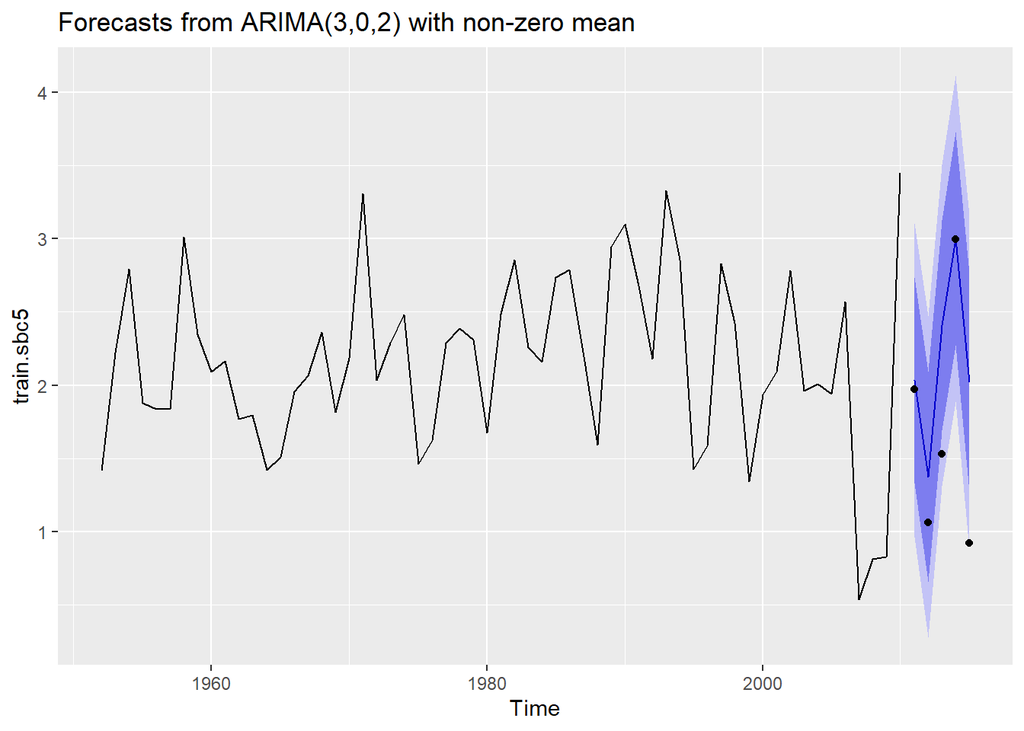

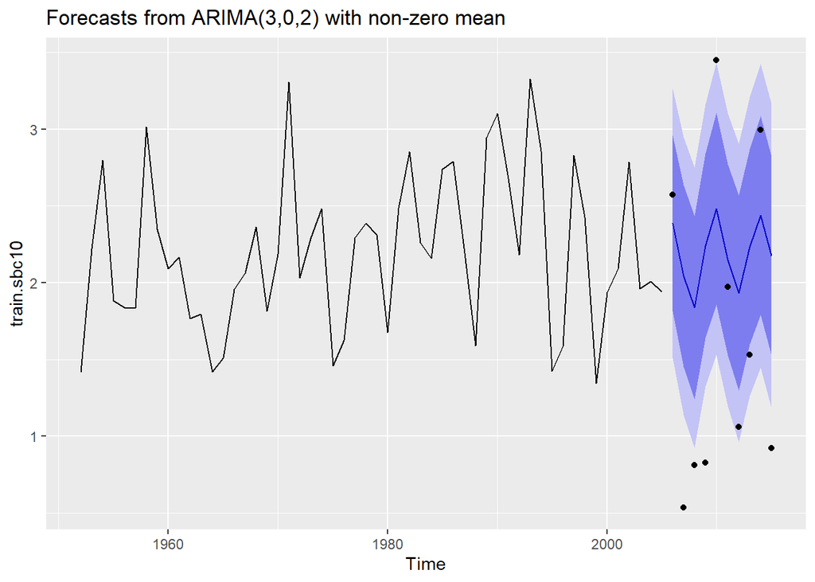

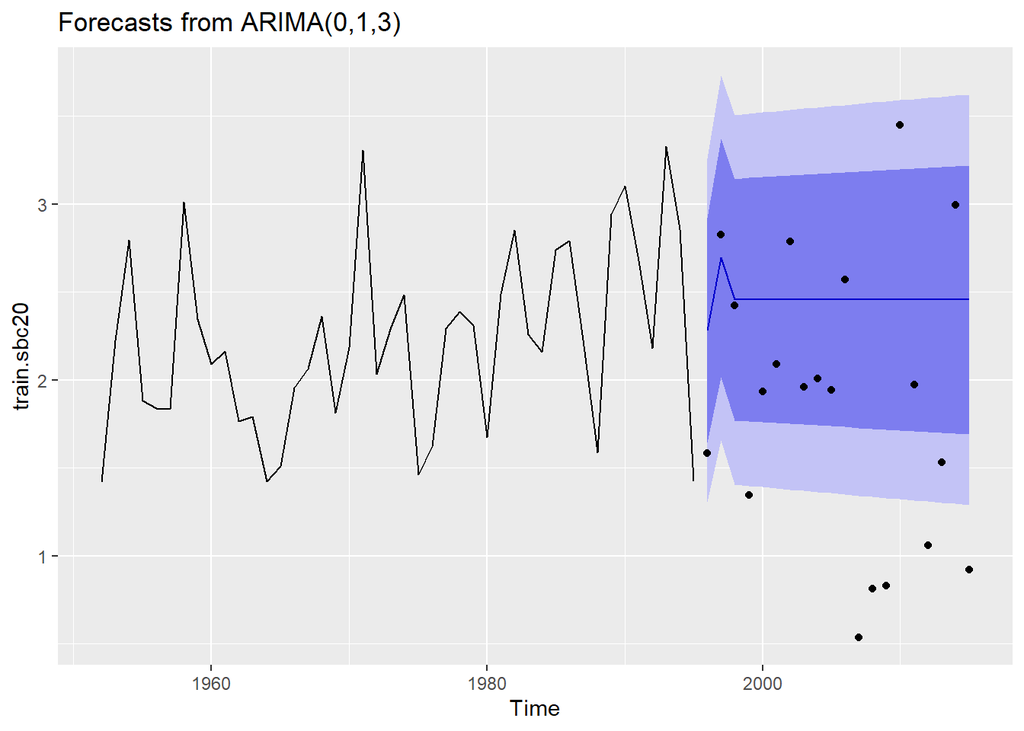

Looking at stationarity:

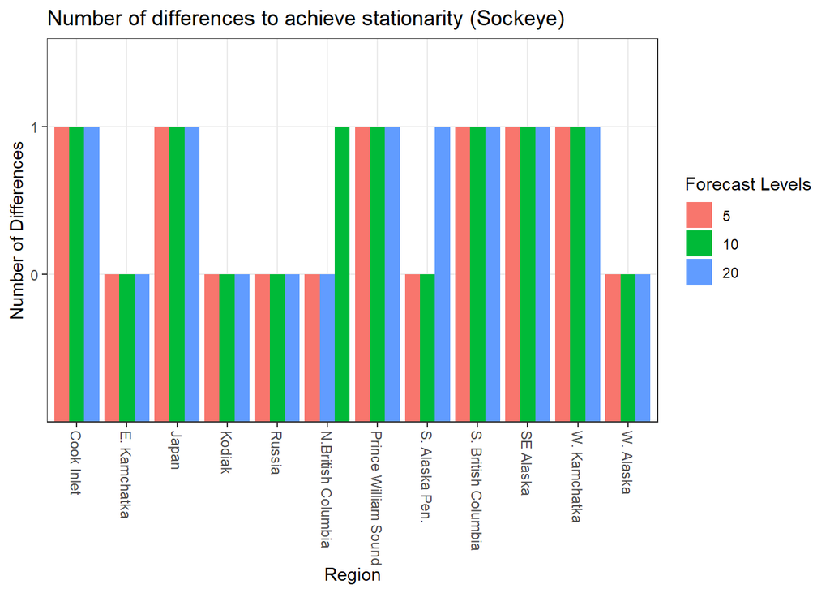

```r
Ndiff<-sapply(RegionBestModSock, function(x){
  a<-strsplit(strsplit(strsplit(x, "[(]")[[1]][2], "[)]")[[1]][1],"[,]")
  return(a[[1]][2])}
)

tibble(Ndiff = Ndiff, region = Allcombs$regions, level = Allcombs$forecastlevels) %>%
  ggplot() + geom_bar(aes(x = region, y = Ndiff, fill = as.factor(level)), stat = "identity", position = "dodge") +
  scale_x_discrete(labels = as_labeller(regionskey)) +
  labs(fill = "Forecast Levels", x = "Region", y = "Number of Differences") +
  ggtitle("Number of differences to achieve stationarity (Sockeye)") + theme_bw() + theme(axis.text.x=element_text(angle=-90, hjust = 0, vjust = 0.5 ))
```

For Sockeye, 6 regions required differencing for all of the three subsets of the data (3 forecasting levels). Two regions required differencing for one subset of the data; four regions were stationary at any level of subsetting.

None of the regional models for the 5-year forecast had autocorrelation in the residuals based on the results of the Ljung-Box test (p-value > 0.05).

## Chum:

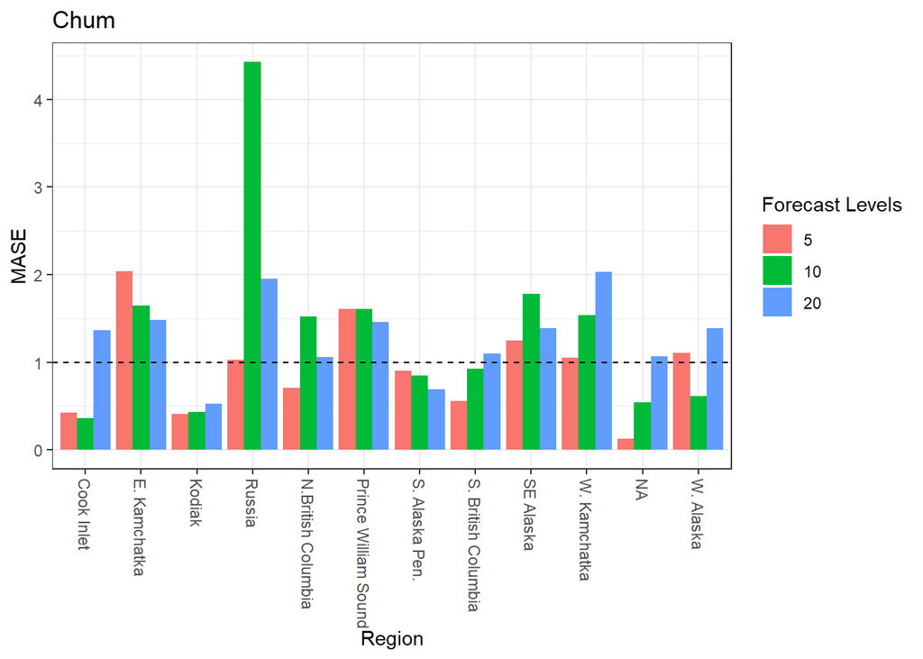

```r
ggplot(ResultsTableChum) +
  geom_bar(aes(x = regions, y = MASE, fill = as.factor(forecastlevels)), stat = "identity", position = "dodge") +
  geom_hline(aes(yintercept = 1), linetype = "dashed") +
  scale_x_discrete(labels = as_labeller(regionskey)) +
  labs(fill = "Forecast Levels", x = "Region") +
  ggtitle("Chum") + theme_bw() + theme(axis.text.x=element_text(angle=-90, hjust = 0, vjust = 0.5 ))
```

Many of the 5 and 10 year forecasts for Chum seem to perform well across regions. Models fit to data in Russia do the worst at forecasting in that region. Additionally, forecasts are poor across the different numbers of years tested in E. Kamachatka, SE Alaska and W. Kamachatka.

20 year forecast for Kodiak:

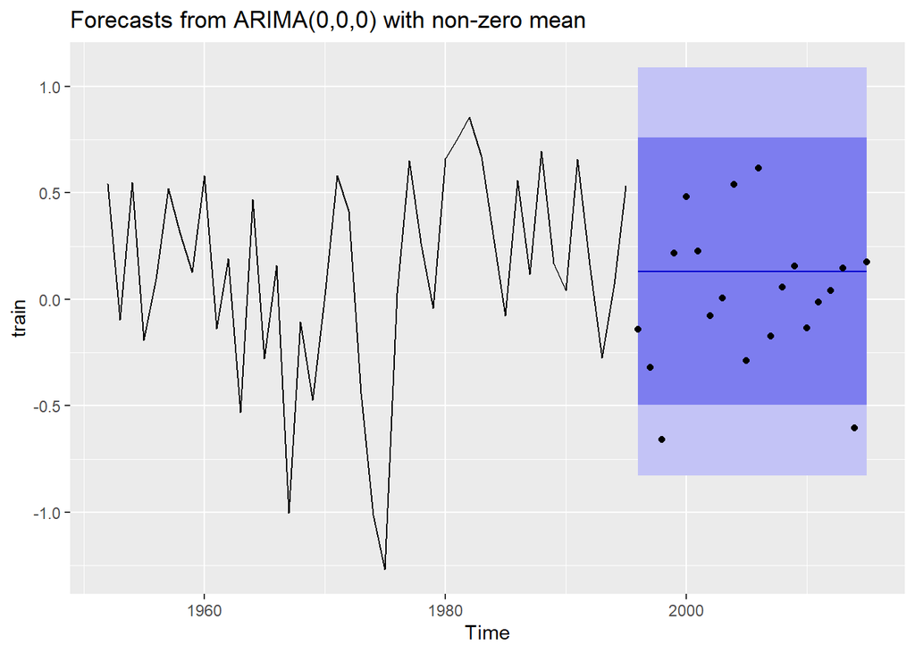

```r
chum.kod<-subset(ChumByRegion, region=='kod')
chum.ts<-ts(chum.kod$lnreturns, start=chum.kod$year[1])
#test datasets for plotting
test.kod20<-window(chum.ts, start=1996, end=2015)
forecast(RegionModsChum[[9]]$Fit, h = 20) %>% autoplot() + geom_point(aes(x=x, y=y), data=fortify(test.kod20))
```

10 year forecast for Russia:

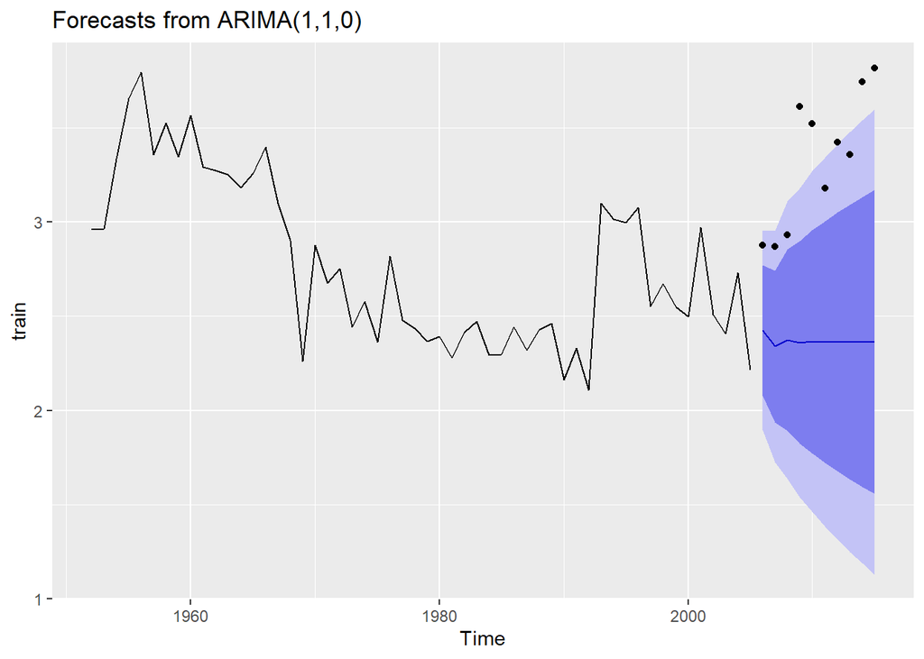

```r
chum.russ<-subset(ChumByRegion, region=='m_i')
chum.ts<-ts(chum.russ$lnreturns, start=chum.russ$year[1])
#test datasets for plotting
test.russ10<-window(chum.ts, start=2006, end=2015)
forecast(RegionModsChum[[11]]$Fit, h = 10) %>% autoplot() + geom_point(aes(x=x, y=y), data=fortify(test.russ10))
```

It looks like returns really increase at the end of the time series in this region, which is likely why ARIMA models don’t forecast this well.

Looking at stationarity:

[figure not shown]

```r
Ndiff<-sapply(RegionBestModChum, function(x){
  a<-strsplit(strsplit(strsplit(x, "[(]")[[1]][2], "[)]")[[1]][1],"[,]")
  return(a[[1]][2])}
)

tibble(Ndiff = Ndiff, region = Allcombs$regions, level = Allcombs$forecastlevels) %>%
  ggplot() + geom_bar(aes(x = region, y = Ndiff, fill = as.factor(level)), stat = "identity", position = "dodge") +
  scale_x_discrete(labels = as_labeller(regionskey)) +
  labs(fill = "Forecast Levels", x = "Region", y = "Number of Differences") +
  ggtitle("Number of differences to achieve stationarity (Chum)") + theme_bw() + theme(axis.text.x=element_text(angle=-90, hjust = 0, vjust = 0.5 ))
```

For Chum, time series for 5 of the regions were stationary (using tests from auto.arima) and 7 required 1 difference to be stationary.

There was significant autocorrelation (based on Ljung-Box test) in 4 of the regional models for Chum:

```r
ac_mods_chum<-c(26, 27, 31, 32) #indexes of models with autocorrelated residuals
for(i in 1:length(ac_mods_chum)){
  print(paste(regionskey[ResultsTableChum$regions[ac_mods_chum[i]]], ResultsTableChum$forecastlevels[ac_mods_chum[i]]))
  checkresiduals(RegionModsChum[[ac_mods_chum[i]]]$Fit)
}
```

```
## [1] "SE Alaska 10"
```

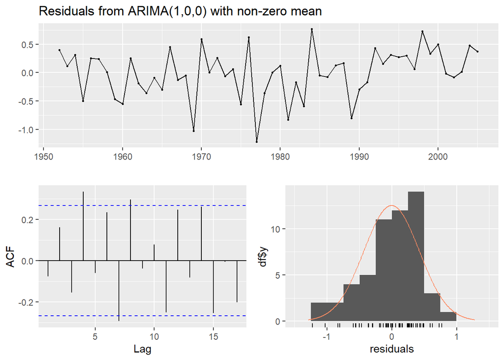

```
##
##  Ljung-Box test
##
## data:  Residuals from ARIMA(1,0,0) with non-zero mean
## Q* = 25.498, df = 9, p-value = 0.002467
##
## Model df: 1.   Total lags used: 10
##
## [1] "SE Alaska 20"
```

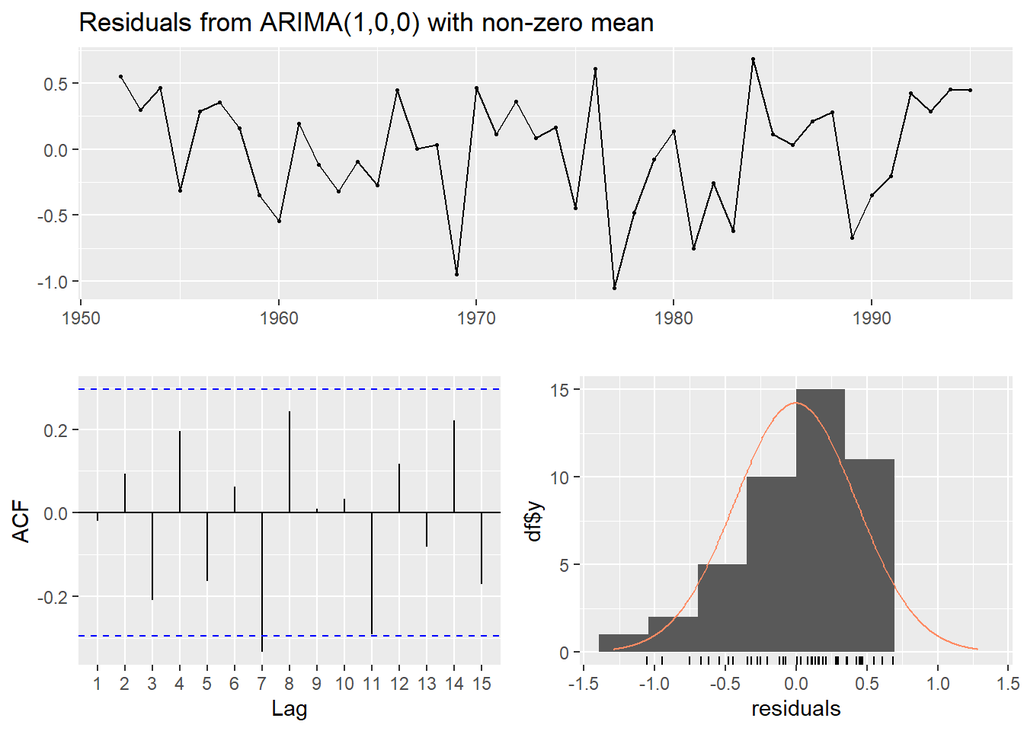

```
##
##  Ljung-Box test
##
## data:  Residuals from ARIMA(1,0,0) with non-zero mean
## Q* = 15.578, df = 8, p-value = 0.04884
##
## Model df: 1.   Total lags used: 9
##
## [1] "NA 5"
```

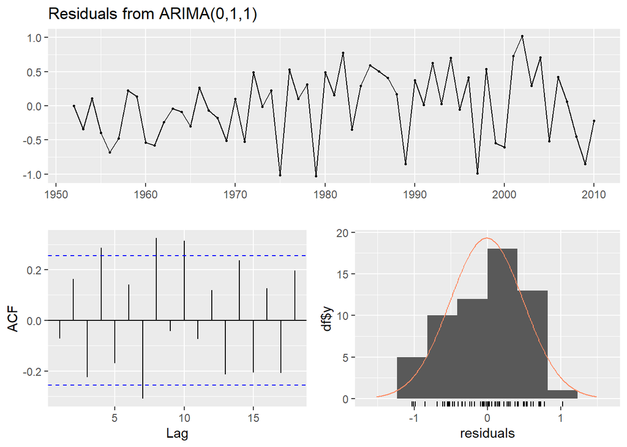

```
##
##  Ljung-Box test
##
## data:  Residuals from ARIMA(0,1,1)
## Q* = 35.287, df = 9, p-value = 5.302e-05
##
## Model df: 1.   Total lags used: 10
##
## [1] "NA 10"
```

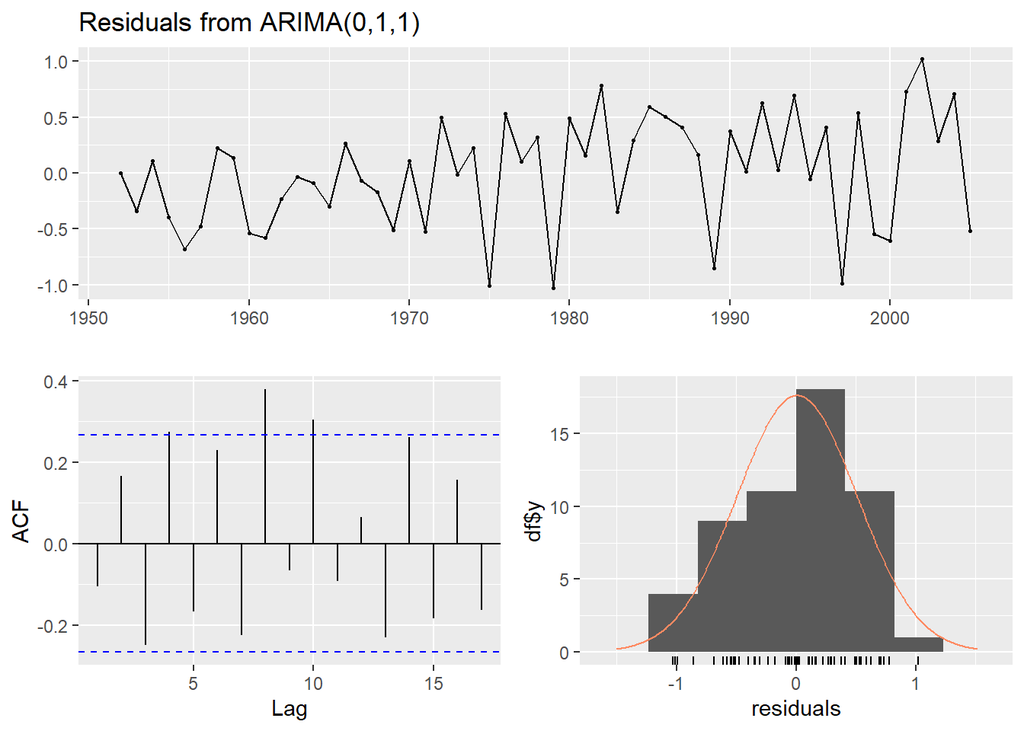

```
##
##  Ljung-Box test
##
## data:  Residuals from ARIMA(0,1,1)
## Q* = 34.843, df = 9, p-value = 6.35e-05
##
## Model df: 1.   Total lags used: 10
```

This suggests that ARIMA models may not be the best fit in this instance.

## Pink:

Plot MASE for three different forecast periods - 5, 10, and 20 years - across all regions. MASE < 1 is a “good” value.

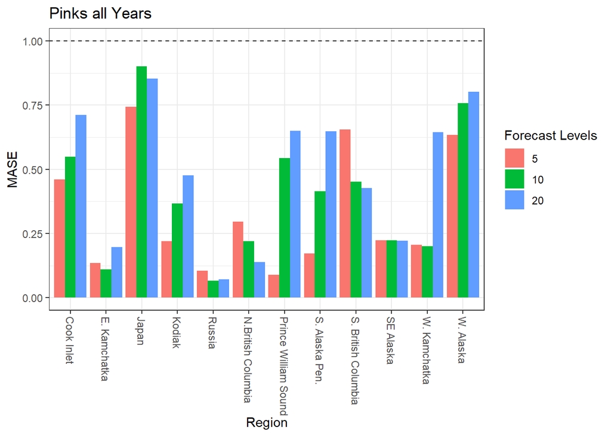

```r
#All Years
ggplot(ResultsTable) +
  geom_bar(aes(x = regions, y = MASE, fill = as.factor(forecastlevels)), stat = "identity", position = "dodge") +
  geom_hline(aes(yintercept = 1), linetype = "dashed") +
  scale_x_discrete(labels = as_labeller(regionskey)) +
  labs(fill = "Forecast Levels", x = "Region") +
  ggtitle("Pinks all Years") + theme_bw() + theme(axis.text.x=element_text(angle=-90, hjust = 0, vjust = 0.5 ))
```

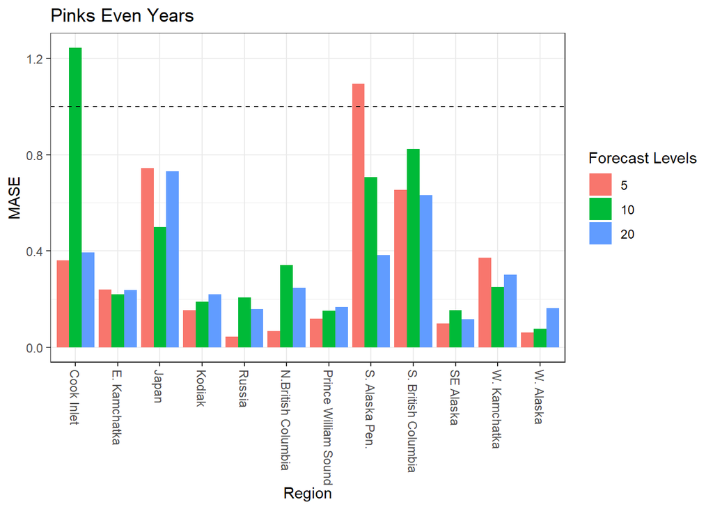

```r
#Even Years
ggplot(ResultsTable_even) +
  geom_bar(aes(x = regions, y = MASE, fill = as.factor(forecastlevels)), stat = "identity", position = "dodge") +
  geom_hline(aes(yintercept = 1), linetype = "dashed") +
  scale_x_discrete(labels = as_labeller(regionskey)) +
  labs(fill = "Forecast Levels", x = "Region") +
  ggtitle("Pinks Even Years") + theme_bw() + theme(axis.text.x=element_text(angle=-90, hjust = 0, vjust = 0.5 ))
```

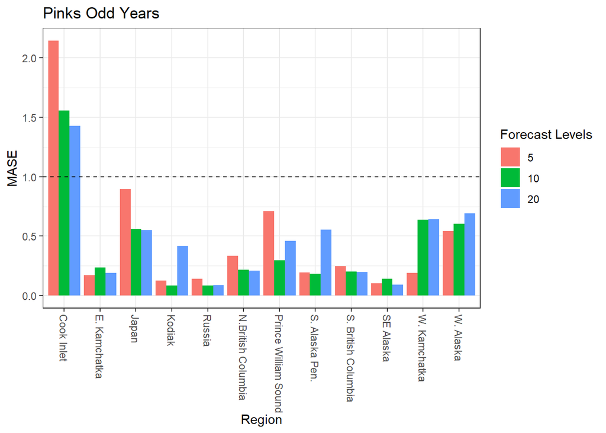

```r
#Odd Years
ggplot(ResultsTable_odd) +
  geom_bar(aes(x = regions, y = MASE, fill = as.factor(forecastlevels)), stat = "identity", position = "dodge") +
  geom_hline(aes(yintercept = 1), linetype = "dashed") +
  scale_x_discrete(labels = as_labeller(regionskey)) +
  labs(fill = "Forecast Levels", x = "Region") +
  ggtitle("Pinks Odd Years") + theme_bw() + theme(axis.text.x=element_text(angle=-90, hjust = 0, vjust = 0.5 ))
```

Despite the MASE fits seeming pretty good for the pink model runs some of the forecasts were underwhelming. Two regions were considered for forcasts, Cook Inlet, and SE Alaska with models that included for all years, even years, and odd years.

The first region, Cook Inlet, performed poorly (relative to some of the other regions) when looking at MASE values.

```r
#Cook Inlet
#----------------------------------------------------
#All Years
pink.ci<-subset(PinkByRegion, region=='ci')
ci.ts<-ts(pink.ci$lnreturns, start=pink.ci$year[1], frequency = 1)

#create training and test datasets for the 5 year forecast
train.ci5<-window(ci.ts, start=1952, end=2010)
test.ci5<-window(ci.ts, start=2011, end=2015)
ci.final5<-forecast::auto.arima(train.ci5, approximation = F, stepwise = F)

#create training and test datasets for the 10 year forecast
train.ci10<-window(ci.ts, start=1952, end=2005)
test.ci10<-window(ci.ts, start=2006, end=2015)
ci.final10<-forecast::auto.arima(train.ci10, approximation = F, stepwise = F)

#create training and test datasets for the 20 year forecast
train.ci20<-window(ci.ts, start=1952, end=1995)
test.ci20<-window(ci.ts, start=1996, end=2015)
ci.final20<-forecast::auto.arima(train.ci20, approximation = F, stepwise = F)

#------------------------------
#Even Years
pink.ci_even<-subset(PinkByRegion_even, region=='ci')
ci.ts_even<-ts(pink.ci_even$lnreturns, start=pink.ci_even$year[1], frequency = 0.5)

#create training and test datasets for the 5 year forecast
train.ci_even5<-window(ci.ts_even, start=1952, end=2010)
test.ci_even5<-window(ci.ts_even, start=2011, end=2014)
ci_even.final5<-forecast::auto.arima(train.ci_even5, approximation = F, stepwise = F)

#create training and test datasets for the 10 year forecast
train.ci_even10<-window(ci.ts_even, start=1952, end=2005)
test.ci_even10<-window(ci.ts_even, start=2006, end=2014)
ci_even.final10<-forecast::auto.arima(train.ci_even10, approximation = F, stepwise = F)

#create training and test datasets for the 20 year forecast
train.ci_even20<-window(ci.ts_even, start=1952, end=1995)
test.ci_even20<-window(ci.ts_even, start=1996, end=2014)
ci_even.final20<-forecast::auto.arima(train.ci_even20, approximation = F, stepwise = F)

#------------------------------
#Odd Years
pink.ci_odd<-subset(PinkByRegion_odd, region=='ci')
ci.ts_odd<-ts(pink.ci_odd$lnreturns, start=pink.ci_odd$year[1], frequency = 0.5)

#create training and test datasets for the 5 year forecast
train.ci_odd5<-window(ci.ts_odd, start=1953, end=2009)
test.ci_odd5<-window(ci.ts_odd, start=2011, end=2015)
ci_odd.final5<-forecast::auto.arima(train.ci_odd5, approximation = F, stepwise = F)

#create training and test datasets for the 10 year forecast
train.ci_odd10<-window(ci.ts_odd, start=1953, end=2005)
test.ci_odd10<-window(ci.ts_odd, start=2007, end=2015)
ci_odd.final10<-forecast::auto.arima(train.ci_odd10, approximation = F, stepwise = F)

#create training and test datasets for the 20 year forecast
train.ci_odd20<-window(ci.ts_odd, start=1953, end=1995)
test.ci_odd20<-window(ci.ts_odd, start=1997, end=2015)
ci_odd.final20<-forecast::auto.arima(train.ci_odd20, approximation = F, stepwise = F)
```

Let’s look at forcast plots for the best performing models that consider all data, even years, and odd years.

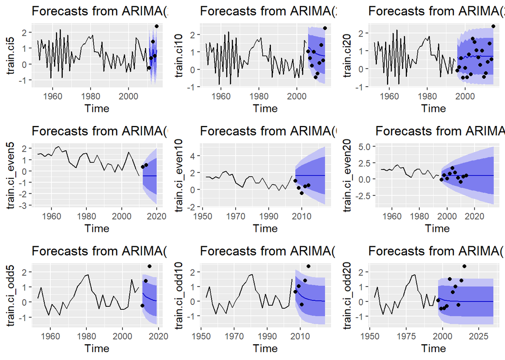

```r
#Plots
plot_5 <- ci.final5 %>%
  forecast(h=5) %>%
  autoplot() + geom_point(aes(x=x, y=y), data=fortify(test.ci5))

plot_10 <- ci.final10 %>%
  forecast(h=10) %>%
  autoplot() + geom_point(aes(x=x, y=y), data=fortify(test.ci10))

plot_20 <- ci.final20 %>%
  forecast(h=20) %>%
  autoplot() + geom_point(aes(x=x, y=y), data=fortify(test.ci20))

plot_even_5 <- ci_even.final5 %>%
  forecast(h=5) %>%
  autoplot() + geom_point(aes(x=x, y=y), data=fortify(test.ci_even5))

plot_even_10 <- ci_even.final10 %>%
  forecast(h=10) %>%
  autoplot() + geom_point(aes(x=x, y=y), data=fortify(test.ci_even10))

plot_even_20 <- ci_even.final20 %>%
  forecast(h=20) %>%
  autoplot() + geom_point(aes(x=x, y=y), data=fortify(test.ci_even20))

plot_odd_5 <- ci_odd.final5 %>%
  forecast(h=5) %>%
  autoplot() + geom_point(aes(x=x, y=y), data=fortify(test.ci_odd5))

plot_odd_10 <- ci_odd.final10 %>%
  forecast(h=10) %>%
  autoplot() + geom_point(aes(x=x, y=y), data=fortify(test.ci_odd10))

plot_odd_20 <- ci_odd.final20 %>%
  forecast(h=20) %>%
  autoplot() + geom_point(aes(x=x, y=y), data=fortify(test.ci_odd20))

plot_grid(plot_5, plot_10, plot_20, plot_even_5, plot_even_10, plot_even_20, plot_odd_5, plot_odd_10, plot_odd_20, ncol = 3, nrow = 3)
```

None of the models fit well. Let’s look at one more region.

```r
#SE AK
#---------------------------------------------------
#All Years
pink.seak<-subset(PinkByRegion, region=='seak')
seak.ts<-ts(pink.seak$lnreturns, start=pink.seak$year[1], frequency = 0.5)

#create training and test datasets for the 5 year forecast
train.seak5<-window(seak.ts, start=1952, end=2010)
test.seak5<-window(seak.ts, start=2011, end=2015)
seak.final5<-forecast::auto.arima(train.seak5, approximation = F, stepwise = F)

#create training and test datasets for the 10 year forecast
train.seak10<-window(seak.ts, start=1952, end=2005)
test.seak10<-window(seak.ts, start=2006, end=2015)
seak.final10<-forecast::auto.arima(train.seak10, approximation = F, stepwise = F)

#create training and test datasets for the 20 year forecast
train.seak20<-window(seak.ts, start=1952, end=1995)
test.seak20<-window(seak.ts, start=1996, end=2015)
seak.final20<-forecast::auto.arima(train.seak20, approximation = F, stepwise = F)

#----------------------------------------------------
#Even Years
pink.seak_even<-subset(PinkByRegion_even, region=='seak')
seak.ts_even<-ts(pink.seak_even$lnreturns, start=pink.seak_even$year[1], frequency = 0.5)

#create training and test datasets for the 5 year forecast
train.seak_even5<-window(seak.ts_even, start=1952, end=2010)
test.seak_even5<-window(seak.ts_even, start=2012, end=2014)
seak_even.final5<-forecast::auto.arima(train.seak_even5, approximation = F, stepwise = F)

#create training and test datasets for the 10 year forecast
train.seak_even10<-window(seak.ts_even, start=1952, end=2004)
test.seak_even10<-window(seak.ts_even, start=2006, end=2014)
seak_even.final10<-forecast::auto.arima(train.seak_even10, approximation = F, stepwise = F)

#create training and test datasets for the 20 year forecast
train.seak_even20<-window(seak.ts_even, start=1952, end=1994)
test.seak_even20<-window(seak.ts_even, start=1996, end=2014)
seak_even.final20<-forecast::auto.arima(train.seak_even20, approximation = F, stepwise = F)

#------------------------------
#Odd Years
pink.seak_odd<-subset(PinkByRegion_odd, region=='seak')
seak.ts_odd<-ts(pink.seak_odd$lnreturns, start=pink.seak_odd$year[1], frequency = 0.5)

#create training and test datasets for the 5 year forecast
train.seak_odd5<-window(seak.ts_odd, start=1953, end=2009)
test.seak_odd5<-window(seak.ts_odd, start=2011, end=2015)
seak_odd.final5<-forecast::auto.arima(train.seak_odd5, approximation = F, stepwise = F)

#create training and test datasets for the 10 year forecast
train.seak_odd10<-window(seak.ts_odd, start=1953, end=2005)
test.seak_odd10<-window(seak.ts_odd, start=2007, end=2015)
seak_odd.final10<-forecast::auto.arima(train.seak_odd10, approximation = F, stepwise = F)

#create training and test datasets for the 20 year forecast
train.seak_odd20<-window(seak.ts_odd, start=1953, end=1995)
test.seak_odd20<-window(seak.ts_odd, start=1997, end=2015)
seak_odd.final20<-forecast::auto.arima(train.seak_odd20, approximation = F, stepwise = F)
```

Let’s look at forcast plots for the best performing models that consider all data, even years, and odd years.

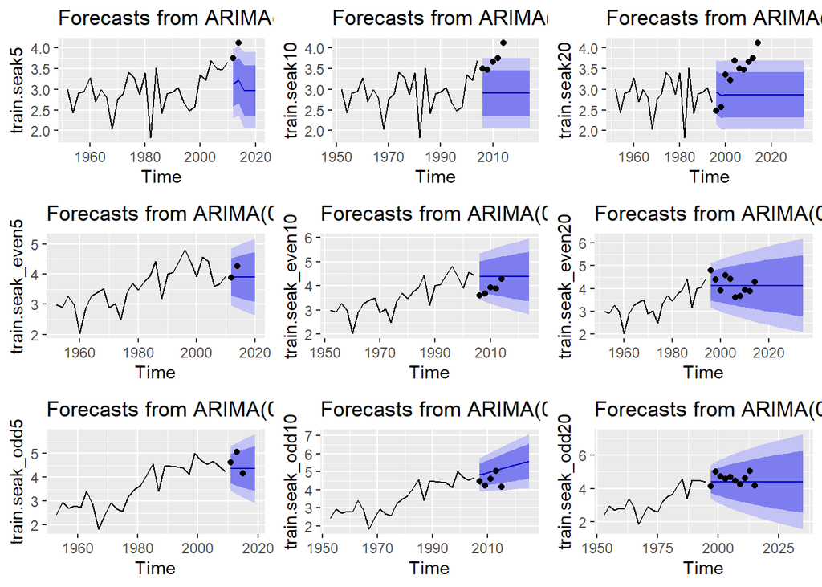

```r
#Plots
plot_5 <- seak.final5 %>%
  forecast(h=5) %>%
  autoplot() + geom_point(aes(x=x, y=y), data=fortify(test.seak5))

plot_10 <- seak.final10 %>%
  forecast(h=10) %>%
  autoplot() + geom_point(aes(x=x, y=y), data=fortify(test.seak10))

plot_20 <- seak.final20 %>%
  forecast(h=20) %>%
  autoplot() + geom_point(aes(x=x, y=y), data=fortify(test.seak20))

plot_even_5 <- seak_even.final5 %>%
  forecast(h=5) %>%
  autoplot() + geom_point(aes(x=x, y=y), data=fortify(test.seak_even5))

plot_even_10 <- seak_even.final10 %>%
  forecast(h=10) %>%
  autoplot() + geom_point(aes(x=x, y=y), data=fortify(test.seak_even10))

plot_even_20 <- seak_even.final20 %>%
  forecast(h=20) %>%
  autoplot() + geom_point(aes(x=x, y=y), data=fortify(test.seak_even20))

plot_odd_5 <- seak_odd.final5 %>%
  forecast(h=5) %>%
  autoplot() + geom_point(aes(x=x, y=y), data=fortify(test.seak_odd5))

plot_odd_10 <- seak_odd.final10 %>%
  forecast(h=10) %>%
  autoplot() + geom_point(aes(x=x, y=y), data=fortify(test.seak_odd10))

plot_odd_20 <- seak_odd.final20 %>%
  forecast(h=20) %>%
  autoplot() + geom_point(aes(x=x, y=y), data=fortify(test.seak_odd20))

plot_grid(plot_5, plot_10, plot_20, plot_even_5, plot_even_10, plot_even_20, plot_odd_5, plot_odd_10, plot_odd_20, ncol = 3, nrow = 3)
```

These models were all pretty flat and also didn’t seem to capture the trends particularly well.

Next, the number of models that had a differencing was plotted for all years, even years, and odd years.

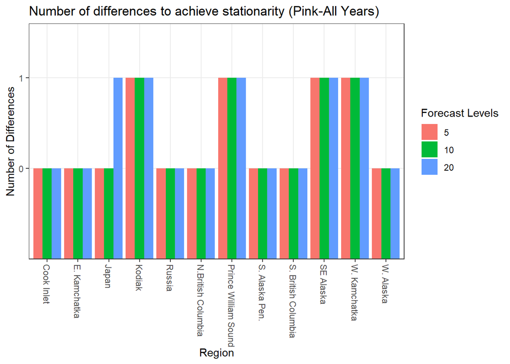

```r
#All Years
Ndiff<-sapply(RegionBestMod, function(x){
  a<-strsplit(strsplit(strsplit(x, "[(]")[[1]][2], "[)]")[[1]][1],"[,]")
  return(a[[1]][2])}
)

tibble(Ndiff = Ndiff, region = Allcombs$regions, level = Allcombs$forecastlevels) %>%
  ggplot() + geom_bar(aes(x = region, y = Ndiff, fill = as.factor(level)), stat = "identity", position = "dodge") +
  scale_x_discrete(labels = as_labeller(regionskey)) +
  labs(fill = "Forecast Levels", x = "Region", y = "Number of Differences") +
  ggtitle("Number of differences to achieve stationarity (Pink-All Years)") + theme_bw() + theme(axis.text.x=element_text(angle=-90, hjust = 0, vjust = 0.5 ))
```

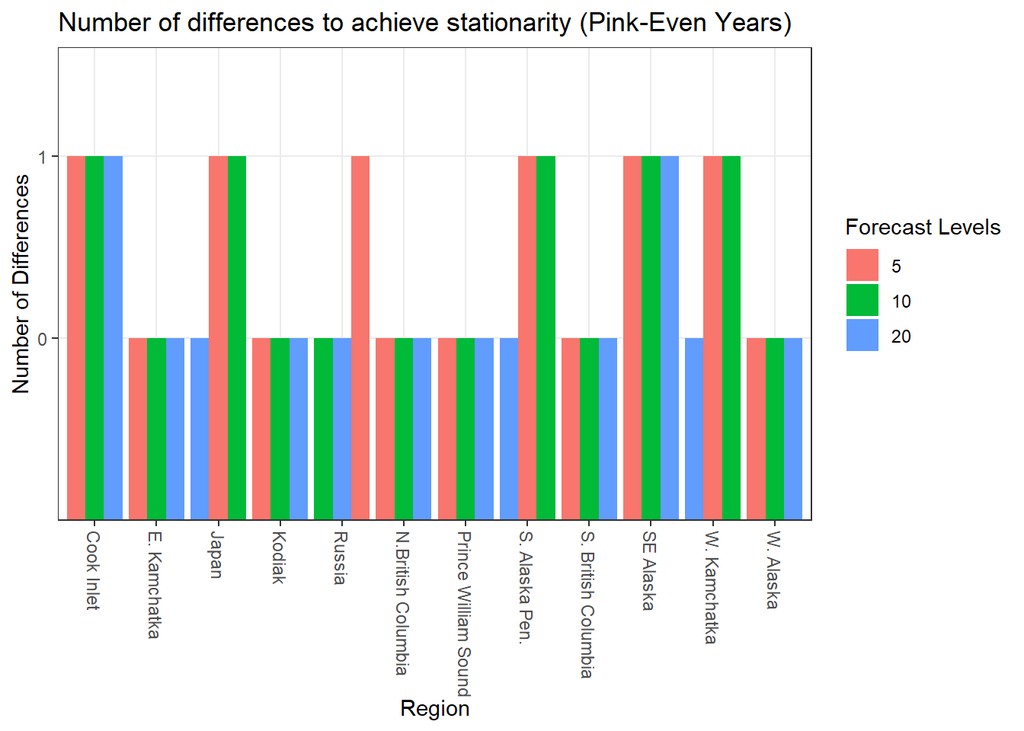

```r
#Even Years
Ndiff_even<-sapply(RegionBestMod_even, function(x){
  a<-strsplit(strsplit(strsplit(x, "[(]")[[1]][2], "[)]")[[1]][1],"[,]")
  return(a[[1]][2])}
)

tibble(Ndiff = Ndiff_even, region = Allcombs$regions, level = Allcombs$forecastlevels) %>%
  ggplot() + geom_bar(aes(x = region, y = Ndiff, fill = as.factor(level)), stat = "identity", position = "dodge") +
  scale_x_discrete(labels = as_labeller(regionskey)) +
  labs(fill = "Forecast Levels", x = "Region", y = "Number of Differences") +
  ggtitle("Number of differences to achieve stationarity (Pink-Even Years)") + theme_bw() + theme(axis.text.x=element_text(angle=-90, hjust = 0, vjust = 0.5 ))
```

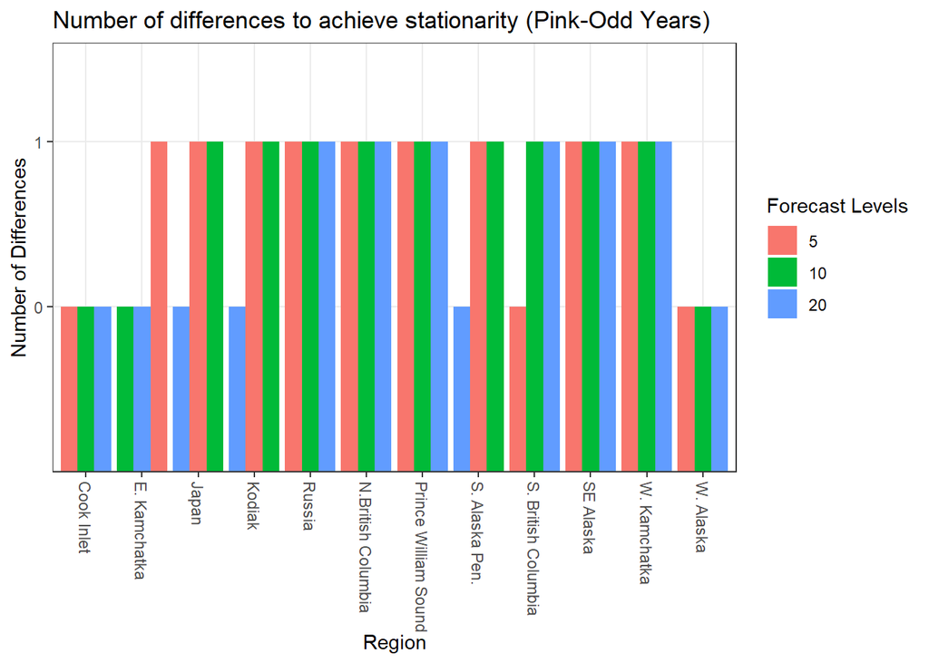

```r
#Odd Years
Ndiff_odd<-sapply(RegionBestMod_odd, function(x){
  a<-strsplit(strsplit(strsplit(x, "[(]")[[1]][2], "[)]")[[1]][1],"[,]")
  return(a[[1]][2])}
)

tibble(Ndiff = Ndiff_odd, region = Allcombs$regions, level = Allcombs$forecastlevels) %>%
  ggplot() + geom_bar(aes(x = region, y = Ndiff, fill = as.factor(level)), stat = "identity", position = "dodge") +
  scale_x_discrete(labels = as_labeller(regionskey)) +
  labs(fill = "Forecast Levels", x = "Region", y = "Number of Differences") +
  ggtitle("Number of differences to achieve stationarity (Pink-Odd Years)") + theme_bw() + theme(axis.text.x=element_text(angle=-90, hjust = 0, vjust = 0.5 ))
```

When considering models that used all data, five regions needed differencing. In models that considered even years only, six regions needed differencing. In models that considered odd years only, ten regions needed differencing.

```r
#Residuals
#all
ac_mods_Pink<- c(10, 11, 15, 29)

for(i in 1:length(ac_mods_Pink)){
print(paste(regionskey[ResultsTable$regions[ac_mods_Pink[i]]], ResultsTable_even$forecastlevels[ac_mods_Pink[i]]))
checkresiduals(RegionMods[[ac_mods_Pink[i]]]$Fit)
}
```

```
## [1] "Kodiak 5"
```

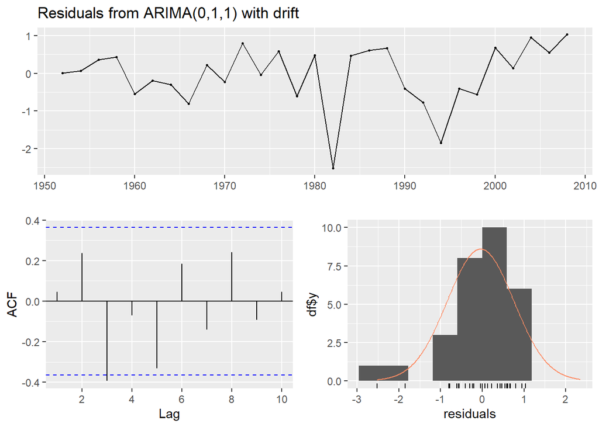

```
##
##  Ljung-Box test
##
## data:  Residuals from ARIMA(0,1,1) with drift
## Q* = 12.949, df = 5, p-value = 0.02386
##
## Model df: 1.   Total lags used: 6
##
## [1] "Kodiak 10"
```

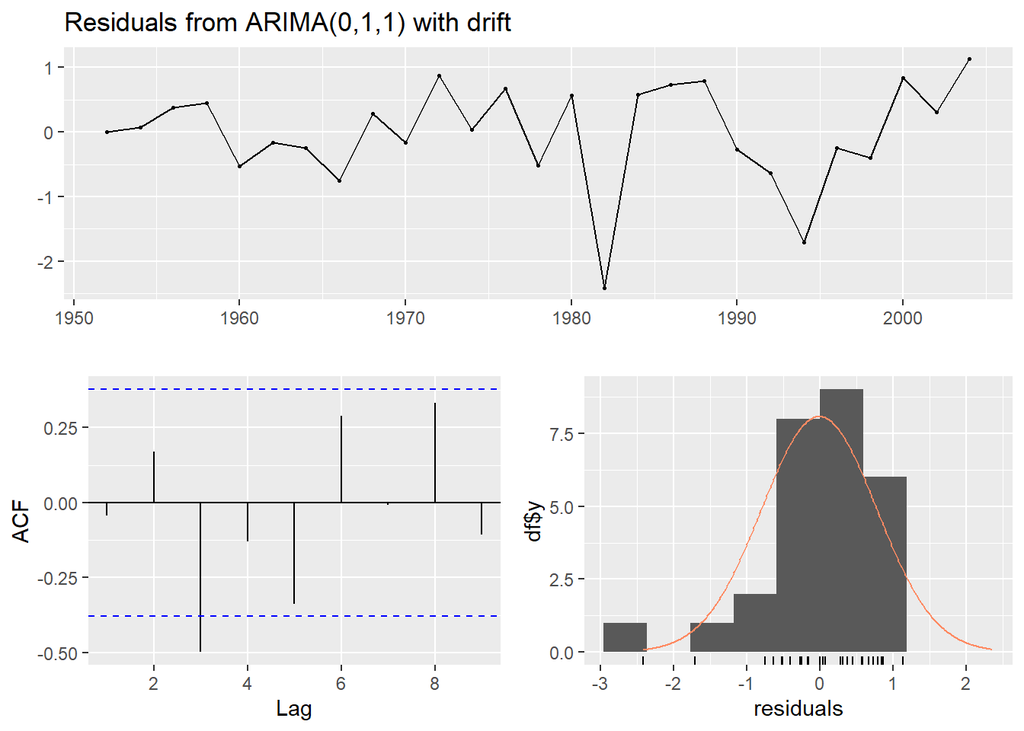

```
##
##  Ljung-Box test
##
## data:  Residuals from ARIMA(0,1,1) with drift
## Q* = 13.668, df = 4, p-value = 0.008432
##
## Model df: 1.   Total lags used: 5
##
## [1] "Russia 20"
```

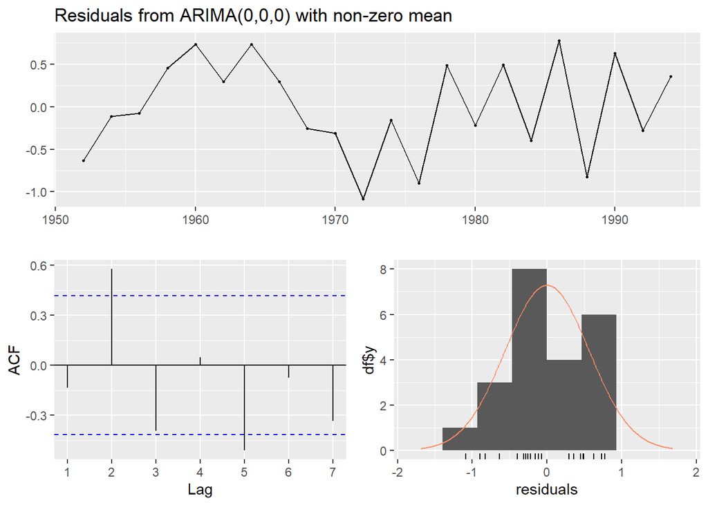

```
##
##  Ljung-Box test
##
## data:  Residuals from ARIMA(0,0,0) with non-zero mean
## Q* = 13.669, df = 4, p-value = 0.008429
##
## Model df: 0.   Total lags used: 4
##
## [1] "SE Alaska 10"
```

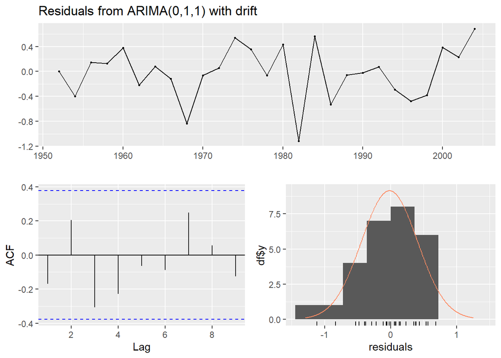

```
##
##  Ljung-Box test
##
## data:  Residuals from ARIMA(0,1,1) with drift
## Q* = 7.1988, df = 4, p-value = 0.1257
##
## Model df: 1.   Total lags used: 5
```

```r
#Even
ac_mods_Pink_even<-c(19, 20)

for(i in 1:length(ac_mods_Pink_even)){
print(paste(regionskey[ResultsTable_even$regions[ac_mods_Pink_even[i]]], ResultsTable_even$forecastlevels[ac_mods_Pink_even[i]]))
checkresiduals(RegionMods_even[[ac_mods_Pink_even[i]]]$Fit)
}
```

```
## [1] "Prince William Sound 5"
```

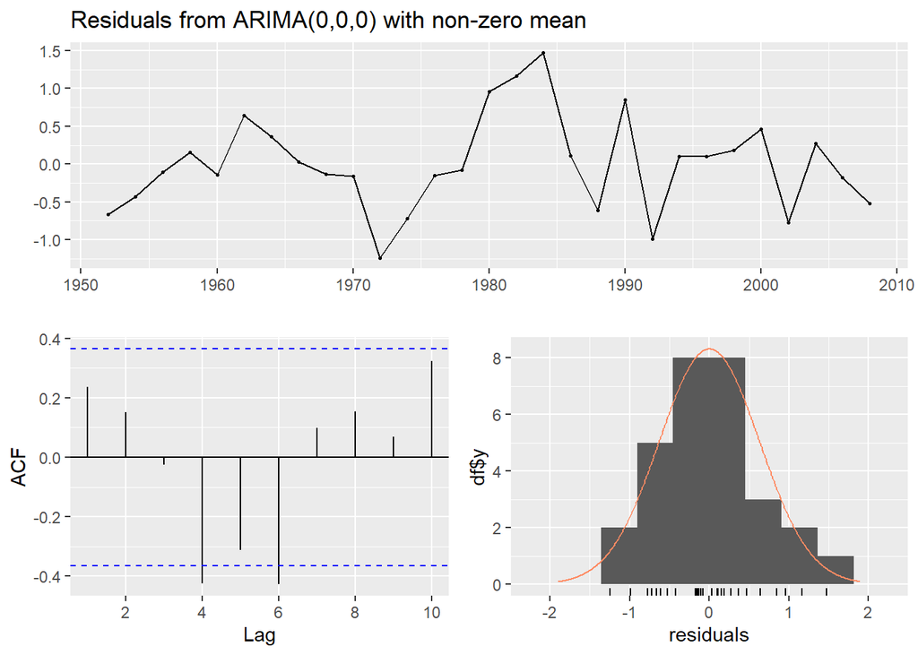

```
##
##  Ljung-Box test
##
## data:  Residuals from ARIMA(0,0,0) with non-zero mean
## Q* = 19.847, df = 6, p-value = 0.002949
##
## Model df: 0.   Total lags used: 6
##
## [1] "Prince William Sound 10"
```

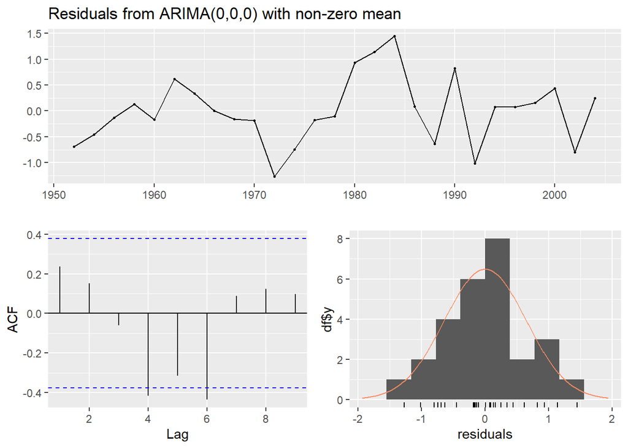

```
##
##  Ljung-Box test
##
## data:  Residuals from ARIMA(0,0,0) with non-zero mean
## Q* = 11.944, df = 5, p-value = 0.03556
##
## Model df: 0.   Total lags used: 5
```

```r
#Odd
ac_mods_Pink_odd<-c(8)

for(i in 1:length(ac_mods_Pink_odd)){
  print(paste(regionskey[ResultsTable_odd$regions[ac_mods_Pink_odd[i]]], ResultsTable_odd$forecastlevels[ac_mods_Pink_odd[i]]))
  checkresiduals(RegionMods_odd[[ac_mods_Pink_odd[i]]]$Fit)
}
```

```
## [1] "Japan 10"
```

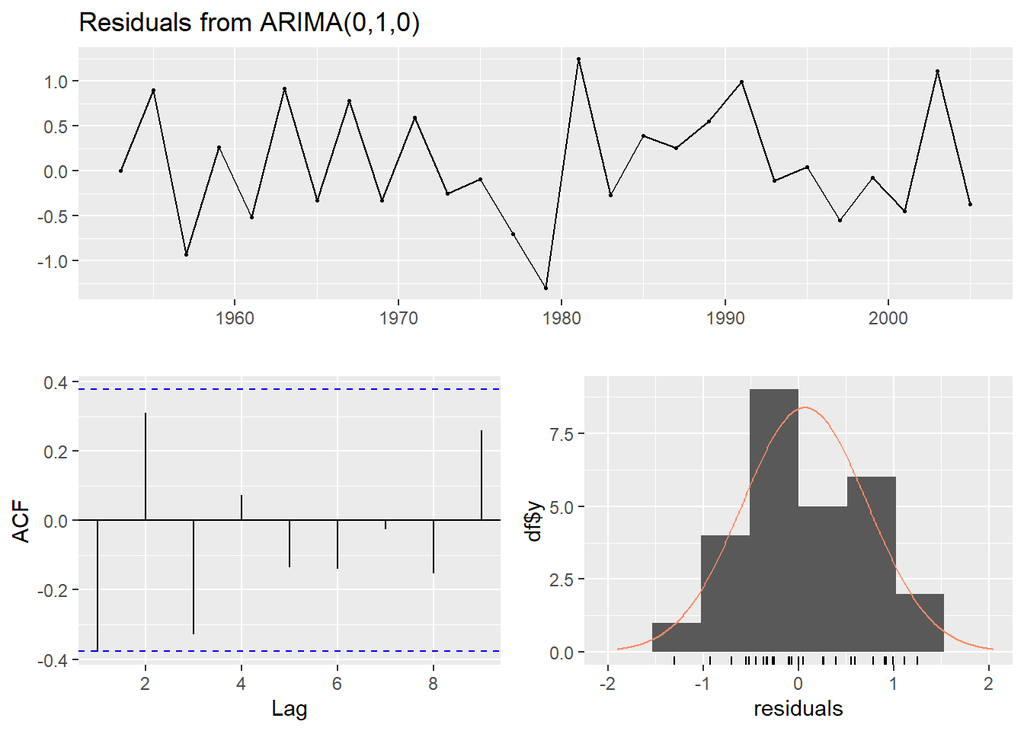

```
##
##  Ljung-Box test
##
## data:  Residuals from ARIMA(0,1,0)
## Q* = 11.71, df = 5, p-value = 0.03899
##
## Model df: 0.   Total lags used: 5
```

#———————————————————————

# Discussion

Comparing the models across the three forecasts for SBC underlines that the data chosen for a forecast matters. Not only is the estimated ARIMA a better fit for a shorter forecast (and is trained on more data), but the training data for the model for the 20 year forecast is not stationary so the ARIMA parameters are very different from the parameters estimated for the 5 and 10 year forecasts.

For sockeye, six regions had at least one forecast with a well performing model (MASE < 1); however, six regions did not have MASE < 1 for even the 5 year forecast model. None of the 20 year forecasts resulted in MASE < 1. This suggests that our data are so stochastic that it is difficult to forecast more than 5 years into the future. Another hypothesis could be that the training data set isn’t long enough to generate a good model for the 20 year forecast, but from looking at the data we think the large inter-year variability in returns makes it difficult to fit an accurate model. In general, the models that fit the data better (lower MASE) tended to include differencing and were more likely to have higher order parameters.

Models fit to Chum do better than models fit to Sockeye. There may be something about the patterns of chum population fluctuations that are more amenable to being modeled with ARIMA.

Model fits to pink depended on data assumptions given their cyclic life history. Unlike other species, notably sockeye, there did not seem to be consistent autocorrelation or identifiable cycles, which makes it hard to predict returns. Many of the models for pink salmon fall back to the long term mean, with ARIMA(0,0,0) models, or alternatively random walk models which define the best estimate as the last onservation. Further, the MASE results were lower than the other stocks, indicating better performance,but ARIMA models are likely not the appropriate method for assessing or predicting pink returns with any level of certainty. Given more time, it would be interesting to explore the forecast models but trimming old data out systematically so the predictions are driven by more recent data.

# Description of each team member’s contributions

All team members helped decide on the goal and ran the analyses for the individual species and all regions. All team members wrote the code and created the results for one species. ZR researched approaches for measuring accuracy of forecasts and created functions to run the ARIMA models over multiple regions and select the best model (even if it was different than selected by auto.arima). ETS and MS modified this code to work with their own species. All team members helped write and edit the report.